# Oscar Dataset Analysis

```r
library(tidyverse)
library(tidyr)
library(janitor)
library(dplyr)
library(ggplot2)
library(tidytext)
library(knitr)
```

**Project Goals**

The goals of our project is to see if there is a correlation between various factors that allow for Best Picture wins to occur. Currently, there is a belief that Oscar Bait exists, which are specific factors that movies follow that increases the chances of winning Oscars.This may include movie run times, movie genres, and the season the movie was released. We want to see if this idea has truth to it and discover if other factors such as critique and audience reviews can impact Oscar wins too.

**About the Data Sources**

**Kaggle:** This dataset includes data starting from 1927 to 2020 that includes Oscar Nominees and Winners for Best Picture. It also includes the genre of each movie and their IMDB and Rotten Tomatoes rating.The grain of this table is Film.

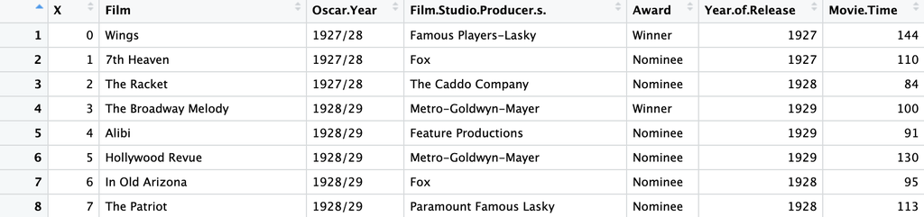

```r
include_graphics("/Users/amrinhaque/Desktop/Data Wrangling/oscar_df_screenshot.png")
```

**Dataful:** This dataset includes data starting from the beginning of the Oscars in 1928 to 2024 that includes all categories of nominations and winners for Oscar nominated movies. The grain of this table is Film.

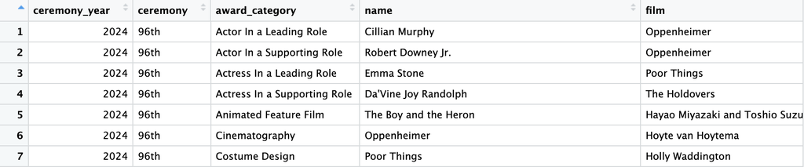

```r
include_graphics("/Users/amrinhaque/Desktop/Data Wrangling/oscar_df2_screenshot.png")
```

**IMDB:** Contains basic details from movies on IMDB, including primary title and isAdults.The grain of this table is primaryTitle and titleType.

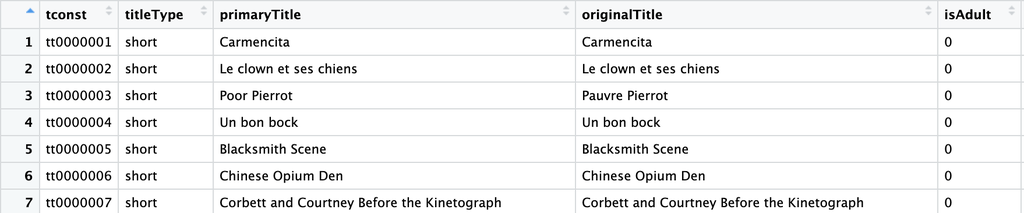

```r
include_graphics("/Users/amrinhaque/Desktop/Data Wrangling/oscar_df3_screenshot.png")
```

**R** For the Bing sentiment analysis, R offers a sentiment lexicon that helps classifies words as either positive or negative.

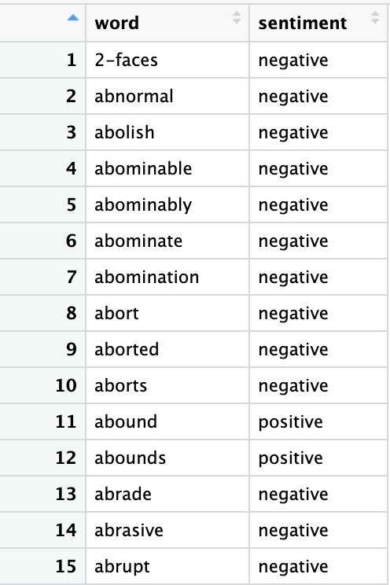

```r
include_graphics("/Users/amrinhaque/Desktop/Data Wrangling/oscar_df4_screenshot.png")
```

*Importing the datasets from Kaggle, Dataful, IMDB, and R*

```r
# Dataset 1: Kaggle
oscar_df1 <- read.csv(
  "/Users/amrinhaque/Desktop/Data Wrangling/oscars_df1.csv"
)

# Dataset 2: Dataful
oscar_df2 <- read.csv(
  "/Users/amrinhaque/Desktop/Data Wrangling/oscars_df2.csv"
)

# Dataset 3: IMDB


oscar_df3 <- read.csv(
  "/Users/amrinhaque/Desktop/Data Wrangling/oscars_df3.csv"
)

# Dataset 4:

oscar_df4 <- read.csv(
  "/Users/amrinhaque/Desktop/Data Wrangling/oscar_df4.csv",
)
```

Selecting relevant columns for analysis, excluding unnecessary ones. Using `clean_names` from the `janitor` package to standardize column names for consistency and ease of use.

```r
oscar_df101 <- oscar_df1 |>
  select(
    Film,
    Film.Studio.Producer.s.,
    Award,
    Year.of.Release,
    Movie.Time,
    Movie.Genre,
    IMDB.Rating,
    IMDB.Votes,
    Critic.Consensus,
    Audience.Rating,
    Audience.Count
  ) |>
  clean_names()
```

Renaming columns with spaces to underscores for consistency. After some critiques, we changed the movie_time(mins) to movie_time_mins to reduce the confusion for column names.

```r
oscar_df102 <- oscar_df101 |>
  rename(
    producer_name = film_studio_producer_s,
    year = year_of_release,
    movie_time_mins = movie_time
  )

# Displaying a glimpse of the renamed dataset
glimpse(oscar_df102)
```

```
Rows: 571
Columns: 11
$ film             <chr> "Wings", "7th Heaven", "The Racket", "The Broadway Me…
$ producer_name    <chr> "Famous Players-Lasky", "Fox", "The Caddo Company", "…
$ award            <chr> "Winner", "Nominee", "Nominee", "Winner", "Nominee", …
$ year             <int> 1927, 1927, 1928, 1929, 1929, 1929, 1928, 1928, 1930,…
$ movie_time_mins  <int> 144, 110, 84, 100, 91, 130, 95, 113, 152, 87, 90, 84,…
$ movie_genre      <chr> "Drama,Romance,War", "Drama,Romance", "Crime,Drama,Fi…
$ imdb_rating      <dbl> 7.5, 7.7, 6.7, 5.7, 5.8, 5.7, 5.6, 7.4, 8.1, 7.1, 6.2…
$ imdb_votes       <chr> "12,221", "3,439", "1,257", "6,890", "765", "2,004", …
$ critic_consensus <chr> "Subsequent war epics may have borrowed heavily from …
$ audience_rating  <dbl> 78, NA, NA, 21, NA, NA, 38, NA, NA, 69, NA, NA, NA, 2…
$ audience_count   <dbl> 3530, NA, NA, 1813, NA, NA, 356, NA, NA, 323, NA, NA,…
```

After importing the data from a CSV file into R, we validated that all columns had the correct data types, except for the `award` and `imdb_votes` columns, which we updated to the appropriate data types.

```r
oscar_df103 <- oscar_df102 |>
  mutate(
    # Removing commas and converting imdb_votes to numeric
    imdb_votes = as.numeric(gsub(",", "", imdb_votes)),

    # Converting the award column to a factor
    award = as.factor(award),

    # Creating a join key by converting the film names to uppercase
    join_key = toupper(film)
  )

# Displaying a glimpse of the updated dataset
glimpse(oscar_df103)
```

```
Rows: 571
Columns: 12
$ film             <chr> "Wings", "7th Heaven", "The Racket", "The Broadway Me…
$ producer_name    <chr> "Famous Players-Lasky", "Fox", "The Caddo Company", "…
$ award            <fct> Winner, Nominee, Nominee, Winner, Nominee, Nominee, N…
$ year             <int> 1927, 1927, 1928, 1929, 1929, 1929, 1928, 1928, 1930,…
$ movie_time_mins  <int> 144, 110, 84, 100, 91, 130, 95, 113, 152, 87, 90, 84,…
$ movie_genre      <chr> "Drama,Romance,War", "Drama,Romance", "Crime,Drama,Fi…
$ imdb_rating      <dbl> 7.5, 7.7, 6.7, 5.7, 5.8, 5.7, 5.6, 7.4, 8.1, 7.1, 6.2…
$ imdb_votes       <dbl> 12221, 3439, 1257, 6890, 765, 2004, 1019, 18, 59214, …
$ critic_consensus <chr> "Subsequent war epics may have borrowed heavily from …
$ audience_rating  <dbl> 78, NA, NA, 21, NA, NA, 38, NA, NA, 69, NA, NA, NA, 2…
$ audience_count   <dbl> 3530, NA, NA, 1813, NA, NA, 356, NA, NA, 323, NA, NA,…
$ join_key         <chr> "WINGS", "7TH HEAVEN", "THE RACKET", "THE BROADWAY ME…
```

Since oscar_df1 originally included both the movie release year and the Oscar ceremony year (e.g., 1927/28, where 1927 is the release year and 1928 is the ceremony year), while oscar_df2 only included the ceremony year, we needed to standardize the data to match the tables. To keep the process simple, we decided to use the Oscar ceremony year consistently across both datasets. This meant removing the movie release year from oscar_df1 and adjusting it so that the year matched the ceremony year in oscar_df2. To achieve this, we added 1 to the movie release year in oscar_df1 to align it with the ceremony year in oscar_df2. This ensured a clean and consistent match between the two datasets.

```r
# The oscar year is behind in dataframe1 (Table1), so we added 1 year to match it across all tables
oscar_df104 <- oscar_df103 |>
  mutate(
    year = year + 1  # Adding 1 year to the 'year' column
  )
```

The existing table classifies genres in a very generic way, so we are reclassifying them into a set of specific genres.

```r
oscar_df105 <- oscar_df104 |>
  mutate(
    movie_genre_1 = case_when(
      grepl("Drama|History|Biography", movie_genre) ~ "Drama",
      grepl("Comedy|Romance|Musical|Family|Fantasy", movie_genre) ~ "Comedy",
      grepl("Action|Adventure|Crime|Thriller|Sci-Fi", movie_genre) ~ "Action/Adventure",
      grepl("Crime|Thriller|Mystery|Film-Noir", movie_genre) ~ "Crime/Thriller/Mystery",
      grepl("Musical|Music", movie_genre) ~ "Musical/Music",
      grepl("Sci-Fi|Fantasy", movie_genre) ~ "Fantasy/Sci-Fi",
      grepl("Family|Animation", movie_genre) ~ "Family/Animation",
      TRUE ~ movie_genre  # Keeping the original genre if no match is found
    )
  )
```

Removing the generic genre column to avoid any confusion. Renaming the updated movie_genre_1 column back to movie_genre

```r
table1 <- oscar_df105 |>
  select(-movie_genre) |>
  rename(
    movie_genre = movie_genre_1
  )
```

** Bing Sentiment Analysis**

In the oscar_df101 table, we analyze the sentiment of movie reviews using the critic_consensus column. For this, we utilize a sentiment lexicon (oscar_df4) provided in R. First, we add a temporary row_id column to uniquely identify each row. Next, the critic_consensus text is broken into individual words (tokenized). These words are matched with the sentiment lexicon (oscar_df4) to determine whether each word is positive or negative. We then count the occurrences of positive and negative words for each review. Using the pivot_wider function, the data is reshaped to create separate columns for positive and negative word counts. Finally, the overall sentiment is calculated by subtracting the negative count from the positive count. Based on the overall sentiment, the case_when function is used to assign labels: “Positive”, “Negative”, or “Neutral”, depending on whether the sentiment score is high, low, or moderate.

```r
# Calculate sentiment scores for each row in oscar_df101
sentiment_results <- oscar_df101 |>
  mutate(row_id = row_number()) |> # Add a temporary row ID for tracking rows
  unnest_tokens(word, critic_consensus) |> # Break down critic consensus text into individual words
  inner_join(oscar_df4, by = "word") |> # Match words with the Bing sentiment lexicon
  count(row_id, sentiment, name = "count") |> # Count occurrences of each sentiment type (positive/negative) by row
  pivot_wider(
    names_from = sentiment,  # Pivot sentiment types (positive/negative) into separate columns
    values_from = count,     # Fill these columns with the sentiment counts
    values_fill = 0          # Replace missing values with 0
  ) |>
  mutate(overall_sentiment = positive - negative) |> # Calculate the net sentiment score
  select(row_id, overall_sentiment) # Keep only row_id and the calculated sentiment score

# Add sentiment labels to the original oscar_df101 dataset
oscar_df_with_sentiment <- oscar_df101 |>
  mutate(row_id = row_number()) |> # Add a temporary row ID for joining
  left_join(sentiment_results, by = "row_id") |> # Join calculated sentiment scores with the original dataset
  mutate(
    # Assign sentiment labels based on the overall sentiment score
    sentiment_label = case_when(
      overall_sentiment > 2 ~ "Positive",   # Highly positive sentiment
      overall_sentiment < -2 ~ "Negative", # Highly negative sentiment
      TRUE ~ "Neutral"                     # Moderate or neutral sentiment
    )
  ) |>
  select(-row_id, -overall_sentiment) # Remove temporary columns to clean up the final dataset

# Displaying the first 5 rows of the updated dataset
print(head(oscar_df_with_sentiment, 5))
```

```
                 film film_studio_producer_s   award year_of_release movie_time
1               Wings   Famous Players-Lasky  Winner            1927        144
2          7th Heaven                    Fox Nominee            1927        110
3          The Racket      The Caddo Company Nominee            1928         84
4 The Broadway Melody    Metro-Goldwyn-Mayer  Winner            1929        100
5               Alibi    Feature Productions Nominee            1929         91
            movie_genre imdb_rating imdb_votes
1     Drama,Romance,War         7.5     12,221
2         Drama,Romance         7.7      3,439
3 Crime,Drama,Film-Noir         6.7      1,257
4 Drama,Musical,Romance         5.7      6,890
5  Action,Crime,Romance         5.8        765
                                                                                                                                                                         critic_consensus
1 Subsequent war epics may have borrowed heavily from the original Best Picture winner, but they've all lacked Clara Bow's luminous screen presence and William Wellman's deft direction.
2
3
4                                  The Broadway Melody is interesting as an example of an early Hollywood musical, but otherwise, it's essentially bereft of appeal for modern audiences.
5
  audience_rating audience_count sentiment_label
1              78           3530        Positive
2              NA             NA         Neutral
3              NA             NA         Neutral
4              21           1813         Neutral
5              NA             NA         Neutral
```

**Table 2**

In Table 2 for the year 2024, the film names and actor names were placed in the incorrect columns. To resolve this, I created temporary columns and assigned the correct film and actor names to their respective columns for 2024.

```r
# Filtering for 'Best Picture' award category
oscar_df201 <- oscar_df2 |>
  filter(award_category == 'Best Picture') |>
  select(everything())

# Creating temporary columns for film and actor names
oscar_df202 <- oscar_df201 |>
  mutate(
    temp_name = name,
    temp_film = film
  )

# Correcting the film and actor columns for 2024
oscar_df203 <- oscar_df202 |>
  mutate(
    film = case_when(ceremony_year == 2024 ~ temp_name, TRUE ~ film),
    name = case_when(ceremony_year == 2024 ~ temp_film, TRUE ~ name),
    join_key = toupper(film)  # Creating a join key based on film names
  )

# Removing temporary columns and renaming 'ceremony_year' to 'year'
table2 <- oscar_df203 |>
  select(-temp_name, -temp_film) |>
  rename(year = ceremony_year)
```

**Table 3**

We wanted to analyze whether the movie rating, such as PG-13 or ADULT, influences Oscar wins. To do this, we are retrieving the ‘isAdult’ column from our third data frame, as it’s not available in the other two tables.

```r
# Filtering for movies and selecting distinct primary title and 'isAdult' columns
oscar_df301 <- oscar_df3 |>
  filter(titleType == 'movie') |>
  select(primaryTitle, isAdult) |>
  distinct()

# Creating a new table with a join key based on the primaryTitle
table3 <- oscar_df301 |>
  mutate(
    join_key = toupper(primaryTitle)  # Converting primaryTitle to uppercase for consistency
  )
```

**Merging Tables**

In this step, we are merging all three tables to create a unified table that will serve as the basis for our analysis.

To join the tables, we first converted the film column to uppercase in all the tables and then performed the join based on this uppercase column, as it provides better coverage for matching.

**Merging 3 tables: table1, table2, and table3 by ‘join_key’**

While joining all three tables, we discovered that one of the tables contained duplicate records, resulting in a many-to-many relationship.

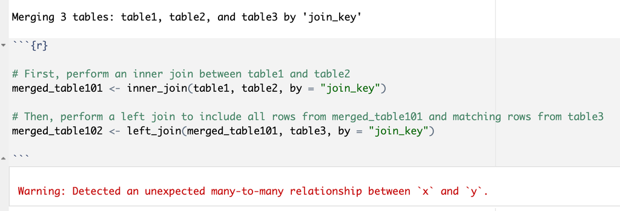

```r
include_graphics("/Users/amrinhaque/Desktop/Data Wrangling/oscar_df_screenshot3.png")
```

```r
ddupe <- oscar_df3 |>
  filter(titleType == 'movie') |>
  group_by(primaryTitle, isAdult) |>
  summarise(count = n(), .groups = 'drop') |>
  filter(count > 1)
```

[figure not shown]

```r
include_graphics("/Users/amrinhaque/Desktop/Data Wrangling/oscar_df_screenshot4.png")
```

After doing root cause analysis we were able to resolve the many-to-many relationship issue. We later joined all 3 tables using the inner_join and left_join function in R considering the “join_key” column that we created within each of the tables.

```r
# First, perform an inner join between table1 and table2
merged_table101 <- inner_join(table1, table2, by = "join_key")

# Then, perform a left join to include all rows from merged_table101 and matching rows from table3
merged_table102 <- left_join(merged_table101, table3, by = "join_key")
```

Selecting only one ‘film’ column after the join and renaming columns for consistency

```r
oscar_table <- merged_table102 |>
  select(
    -film.y,    # Removing duplicate 'film.y' column
    -year.x,    # Removing 'year.x' column
    -primaryTitle,  # Removing 'primaryTitle' column
    -award_category,
    -name,
    -status
  ) |>
  rename(
    film = film.x,  # Renaming 'film.x' to 'film'
    year = year.y   # Renaming 'year.y' to 'year'
  ) |> arrange(desc(year))
```

**Getting into the Analysis:**

We plan to explore the relationship between movie genres and their likelihood of winning the Best Picture award. Additionally, we #want to examine other factors that might influence a film’s success at the Oscars, such as runtime, release season (e.g., movies #released between October and December), and potentially even other variables like budget or the presence of established talent.

By examining these trends and presenting our findings visually, we aim to better understand the nuances of Oscar-winning films and what qualities might enhance a film’s chances of recognition.

**Movie Length (in mins) vs. Oscar Wins**

The box-plots below indicate that Oscar Best Picture winners tend to have a longer average run-time than nominees, with an average length of 132 minutes. Additionally, the overall range of run-times for winners is broader than for nominees. This trend could help explain why films like Oppenheimer, with its 180-minute run time, might have had an edge over shorter contenders.

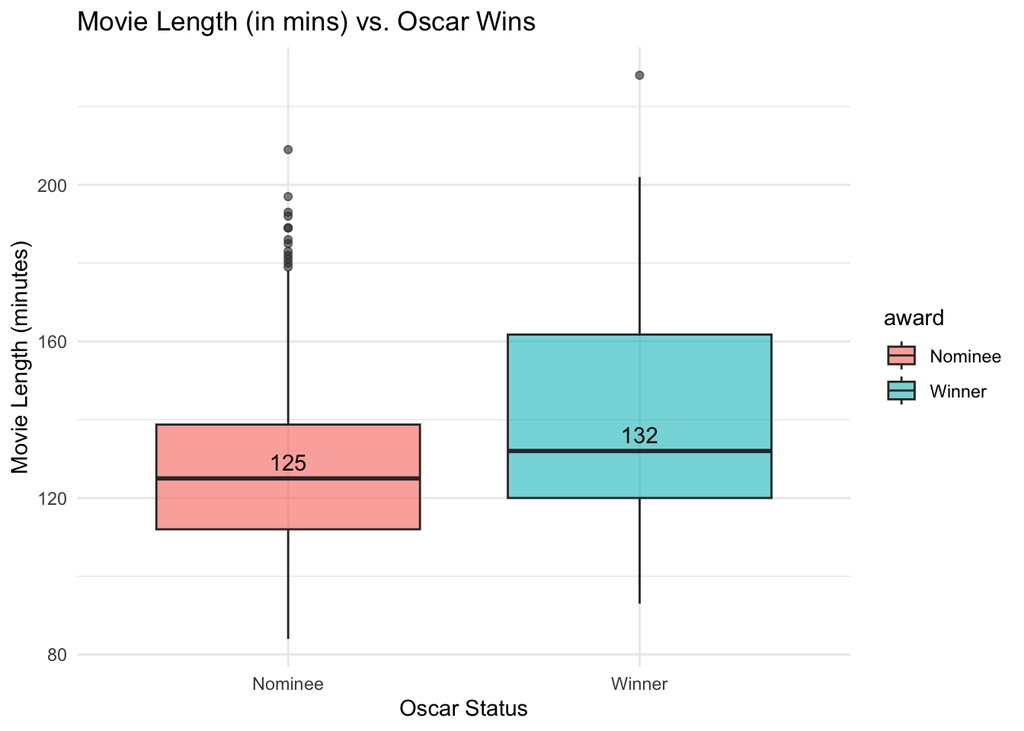

```r
# Violin plot with jitter for movie length by award status
ggplot(oscar_table, aes(x = award, y = `movie_time_mins`, fill = award)) +
  geom_boxplot(alpha = 0.6) +
  stat_summary(fun = median, geom = "text", aes(label = round(..y.., 1)),
               position = position_dodge(width = 0.75), vjust = -0.5, color = "black") +
  labs(title = "Movie Length (in mins) vs. Oscar Wins",
       x = "Oscar Status", y = "Movie Length (minutes)") +
  theme_minimal()
```

**Audience Ratings vs. Oscar Wins**

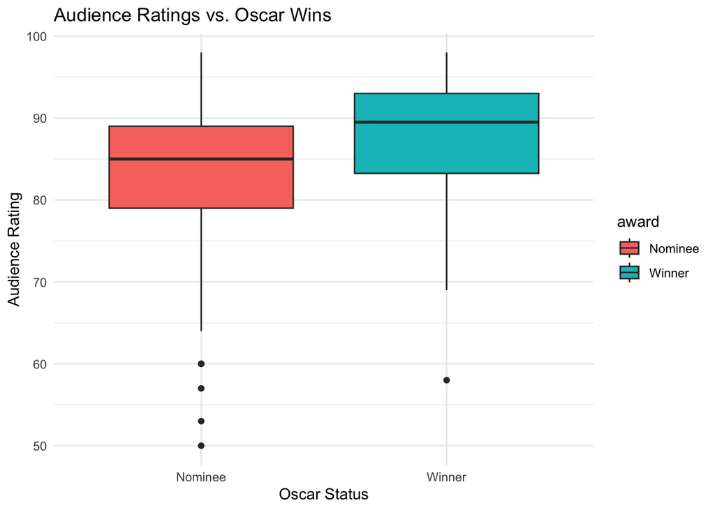

```r
# Box plot of audience rating by award status
ggplot(oscar_table, aes(x = award, y = audience_rating, fill = award)) +
  geom_boxplot() +
  labs(title = "Audience Ratings vs. Oscar Wins",
       x = "Oscar Status", y = "Audience Rating") +
  theme_minimal()
```

**IMDB Votes vs. Oscar Wins**

The box plot below shows that Oscar-winning films tend to receive significantly more IMDb votes compared to Oscar-nominated films, with winners averaging around 352,322 votes and nominees about 140,772 votes. This could suggest that “Oscar bait” films—those crafted to appeal to the Academy—also resonate more with audiences or gain additional attention after winning. While it’s unclear if the votes increase post-win, the data highlights a potential link between popularity and Oscar success.

[figure not shown]

```r
ggplot(oscar_table, aes(x = award, y = imdb_votes, fill = award)) +
  geom_boxplot(alpha = 0.6) +
  stat_summary(fun = median, geom = "text", aes(label = round(..y.., 0)),
               position = position_dodge(width = 0.75), vjust = -0.5, color = "black") +
  labs(title = "IMDb Votes by Oscar Wins Status",
       x = "Oscar Status", y = "IMDb Votes") +
  theme_minimal()
```

**SQL version**

```r
library(DBI)
library(duckdb)
options(duckdb.enable_rstudio_connection_pane=TRUE)

# create / connect to in memory database (not stored in a file)
drv <- duckdb()
con <- dbConnect(drv)
```

*Importing the datasets from Kaggle, Dataful, and IMDB Dataset 1: Kaggle*

```sql
CREATE TABLE oscar_sql1 AS
    SELECT * FROM 'oscars_df1.csv';
```

```sql
CREATE TABLE oscar_sql2 AS
    SELECT * FROM 'oscars_df2.csv';
```

```sql
CREATE TABLE oscar_sql3 AS
SELECT * FROM READ_CSV('oscars_df3.csv',
    DELIM='\t',
    nullstr='\\N',
    HEADER=TRUE,
    IGNORE_ERRORS=TRUE);
```

```sql
CREATE TABLE oscar_sql4 AS
    SELECT * FROM 'oscar_df4.csv';
```

To exclude columns from the table and create a new table from oscar_sq1, we used the **EXCLUDING COLUMNS** function. Initially, the table would create errors but then I realized SQL does not react to “film.studio.producer.s” for example, but reacts to the exact syntax of the table name.

```sql
CREATE TABLE oscar_sql101 AS
SELECT
    Film AS film,
    "Film Studio/Producer(s)" AS film_studio_producers,
    Award AS award,
    "Year of Release" AS year_of_release,
    "Movie Time" AS movie_time,
    "Movie Genre" AS movie_genre,
    "IMDB Rating" AS imdb_rating,
    "IMDB Votes" AS imdb_votes,
    "Critic Consensus" AS critic_consensus,
    "Audience Rating" AS audience_rating,
    "Audience Count" AS audience_count

FROM oscar_sql1;
```

Now we want to change specific names within oscar_sql101, such as the film_studio_producer, year_of_release, and movie_time. To keep the process separate to highliight these specific name changes, I will be implementing the same process of EXCLUDING COLUMNS within this chunk.

```sql
CREATE TABLE oscar_sql102 AS
SELECT
    Film AS film,
    film_studio_producers AS producer_name,
    Award AS award,
    year_of_release AS year,
    movie_time AS movie_time_mins,
    movie_genre AS movie_genre,
    imdb_rating AS imdb_rating,
    imdb_votes AS imdb_votes,
    critic_consensus AS critic_consensus,
    audience_rating AS audience_rating,
    audience_count AS audience_count

FROM oscar_sql101;
```

Previewing the table to ensure it is correct.

```sql
SELECT * FROM oscar_sql102 LIMIT 5;
```

5 records

| film | producer_name | award | year | movie_time_mins | movie_genre | imdb_rating | imdb_votes | critic_consensus | audience_rating | audience_count |
| --- | --- | --- | --- | --- | --- | --- | --- | --- | --- | --- |
| Wings | Famous Players-Lasky | Winner | 1927 | 144 | Drama,Romance,War | 7.5 | 12,221 | Subsequent war epics may have borrowed heavily from the original Best Picture winner, but they’ve all lacked Clara Bow’s luminous screen presence and William Wellman’s deft direction. | 78 | 3530 |
| 7th Heaven | Fox | Nominee | 1927 | 110 | Drama,Romance | 7.7 | 3,439 | NA | NA | NA |
| The Racket | The Caddo Company | Nominee | 1928 | 84 | Crime,Drama,Film-Noir | 6.7 | 1,257 | NA | NA | NA |
| The Broadway Melody | Metro-Goldwyn-Mayer | Winner | 1929 | 100 | Drama,Musical,Romance | 5.7 | 6,890 | The Broadway Melody is interesting as an example of an early Hollywood musical, but otherwise, it’s essentially bereft of appeal for modern audiences. | 21 | 1813 |
| Alibi | Feature Productions | Nominee | 1929 | 91 | Action,Crime,Romance | 5.8 | 765 | NA | NA | NA |

```sql
CREATE TABLE oscar_sql103 AS
SELECT
    *,
    award AS award_factor,
    UPPER(film) AS join_key
FROM oscar_sql102;
```

```sql
SELECT * FROM oscar_sql103 LIMIT 5;
```

5 records

| film | producer_name | award | year | movie_time_mins | movie_genre | imdb_rating | imdb_votes | critic_consensus | audience_rating | audience_count | award_factor | join_key |
| --- | --- | --- | --- | --- | --- | --- | --- | --- | --- | --- | --- | --- |
| Wings | Famous Players-Lasky | Winner | 1927 | 144 | Drama,Romance,War | 7.5 | 12,221 | Subsequent war epics may have borrowed heavily from the original Best Picture winner, but they’ve all lacked Clara Bow’s luminous screen presence and William Wellman’s deft direction. | 78 | 3530 | Winner | WINGS |
| 7th Heaven | Fox | Nominee | 1927 | 110 | Drama,Romance | 7.7 | 3,439 | NA | NA | NA | Nominee | 7TH HEAVEN |
| The Racket | The Caddo Company | Nominee | 1928 | 84 | Crime,Drama,Film-Noir | 6.7 | 1,257 | NA | NA | NA | Nominee | THE RACKET |
| The Broadway Melody | Metro-Goldwyn-Mayer | Winner | 1929 | 100 | Drama,Musical,Romance | 5.7 | 6,890 | The Broadway Melody is interesting as an example of an early Hollywood musical, but otherwise, it’s essentially bereft of appeal for modern audiences. | 21 | 1813 | Winner | THE BROADWAY MELODY |
| Alibi | Feature Productions | Nominee | 1929 | 91 | Action,Crime,Romance | 5.8 | 765 | NA | NA | NA | Nominee | ALIBI |

Adding 1 year to the year column for Table 1 to ensure the year aligns with Table 2

```sql
CREATE TABLE oscar_sql104 AS
SELECT
    *,
    year + 1 AS year
FROM oscar_sql103;
```

The existing table classifies genres in a very generic way, so we are reclassifying them into a set of specific genres.

```sql
CREATE TABLE oscar_sql105 AS
SELECT
    *,
    CASE
        WHEN regexp_matches(movie_genre, 'Drama|History|Biography') THEN 'Drama'
        WHEN regexp_matches(movie_genre, 'Comedy|Romance|Musical|Family|Fantasy') THEN 'Comedy'
        WHEN regexp_matches(movie_genre, 'Action|Adventure|Crime|Thriller|Sci-Fi') THEN 'Action/Adventure'
        WHEN regexp_matches(movie_genre, 'Crime|Thriller|Mystery|Film-Noir') THEN 'Crime/Thriller/Mystery'
        WHEN regexp_matches(movie_genre, 'Musical|Music') THEN 'Musical/Music'
        WHEN regexp_matches(movie_genre, 'Sci-Fi|Fantasy') THEN 'Fantasy/Sci-Fi'
        WHEN regexp_matches(movie_genre, 'Family|Animation') THEN 'Family/Animation'
        ELSE movie_genre
    END AS movie_genre_1
FROM oscar_sql104;
```

**Creating Table 1**

Removing the generic genre column to avoid any confusion. Renaming the updated movie_genre_1 column back to movie_genre. Also removing the original award category and including the award_factor column and the year_1 (changing to year) column to accommodate the revisions so that the table can easily join with table 2 and 3.

```sql
CREATE TABLE table1sql AS
SELECT
    film,
    producer_name,
    movie_time_mins,
    imdb_rating,
    imdb_votes,
    critic_consensus,
    audience_rating,
    audience_count,
    award_factor AS award,
    year_1 AS year,
    join_key,
    movie_genre_1 AS movie_genre,
FROM oscar_sql105;
```

**Bing Sentiment Analysis for SQL**

In the oscar_sql101 table, we performed sentiment analysis on movie reviews using the critic_consensus column. This analysis utilized a sentiment lexicon (oscar_sql4) to classify words as positive or negative. First, a unique row_id was generated for each row using the ROW_NUMBER() function to ensure accurate tracking. The text in the critic_consensus column was then tokenized into individual words using STRING_SPLIT and UNNEST. These tokenized words were matched with the sentiment lexicon to identify their sentiment polarity. Next, we counted the occurrences of positive and negative words for each review, grouping the results by row_id. The counts were then reshaped to separate positive and negative word counts into distinct columns. The overall sentiment score was computed by subtracting the negative count from the positive count. Finally, sentiment labels—“Positive,” “Negative,” or “Neutral”—were assigned based on the overall sentiment score, providing a comprehensive analysis of the sentiment expressed in the movie reviews.

```sql
--Add row_id to the original dataset for consistent referencing
WITH original_data AS (
    SELECT
        ROW_NUMBER() OVER () AS row_id,
        *
    FROM oscar_sql101
),

--Tokenize text
tokenized_text AS (
    SELECT
        od.row_id, -- Use consistent row_id from original_data
        UNNEST(STRING_SPLIT(od.critic_consensus, ' ')) AS word
    FROM original_data od
),

--Join tokenized words with sentiment lexicon
matched_sentiment AS (
    SELECT
        t.row_id,
        t.word,
        s.sentiment
    FROM tokenized_text t
    LEFT JOIN oscar_sql4 s ON LOWER(t.word) = LOWER(s.word)
),

--Count occurrences of each sentiment type
sentiment_counts AS (
    SELECT
        row_id,
        sentiment,
        COUNT(*) AS count
    FROM matched_sentiment
    WHERE sentiment IS NOT NULL
    GROUP BY row_id, sentiment
),

--Pivot sentiment counts
pivoted_sentiments AS (
    SELECT
        row_id,
        COALESCE(SUM(CASE WHEN sentiment = 'positive' THEN count END), 0) AS positive_count,
        COALESCE(SUM(CASE WHEN sentiment = 'negative' THEN count END), 0) AS negative_count
    FROM sentiment_counts
    GROUP BY row_id
),

--Calculate overall sentiment and assign sentiment label
calculated_sentiment AS (
    SELECT
        row_id,
        positive_count - negative_count AS overall_sentiment,
        CASE
            WHEN positive_count - negative_count > 2 THEN 'Positive'
            WHEN positive_count - negative_count < -2 THEN 'Negative'
            ELSE 'Neutral'
        END AS sentiment_label
    FROM pivoted_sentiments
)

--Combine original data with sentiment analysis
SELECT
    od.*,
    cs.sentiment_label
FROM original_data od
LEFT JOIN calculated_sentiment cs
ON od.row_id = cs.row_id;
```

Displaying records 1 - 10

| row_id | film | film_studio_producers | award | year_of_release | movie_time | movie_genre | imdb_rating | imdb_votes | critic_consensus | audience_rating | audience_count | sentiment_label |
| --- | --- | --- | --- | --- | --- | --- | --- | --- | --- | --- | --- | --- |
| 1 | Wings | Famous Players-Lasky | Winner | 1927 | 144 | Drama,Romance,War | 7.5 | 12,221 | Subsequent war epics may have borrowed heavily from the original Best Picture winner, but they’ve all lacked Clara Bow’s luminous screen presence and William Wellman’s deft direction. | 78 | 3530 | Neutral |
| 4 | The Broadway Melody | Metro-Goldwyn-Mayer | Winner | 1929 | 100 | Drama,Musical,Romance | 5.7 | 6,890 | The Broadway Melody is interesting as an example of an early Hollywood musical, but otherwise, it’s essentially bereft of appeal for modern audiences. | 21 | 1813 | Neutral |
| 14 | Cimarron | RKO Radio | Winner | 1931 | 123 | Drama,Western | 5.9 | 5,851 | Cimarron is supported by a strong performance from Irene Dunne, but uneven in basically every other regard, and riddled with potentially offensive stereotypes. | 25 | 1514 | Neutral |
| 27 | Cavalcade | Fox | Winner | 1933 | 112 | Drama,Romance,War | 5.9 | 4,961 | Though solidly acted and pleasant to look at, Cavalcade lacks cohesion, and sacrifices true emotion for mawkishness. | 26 | 1027 | Neutral |
| 28 | 42nd Street | Warner Bros. | Nominee | 1933 | 89 | Comedy,Drama,Musical | 7.4 | 11,342 | Bubsy Berkeley does it again in 42nd Street, a brilliant depression-era romp with stellar musical numbers and impeccable choreography. | 74 | 7561 | Positive |
| 34 | She Done Him Wrong | Paramount | Nominee | 1933 | 66 | Comedy,Drama,History | 6.4 | 5,899 | She Done Him Wrong, but putting Cary Grant and Mae West together is pretty much nothing but right. | 53 | 2240 | Neutral |
| 37 | It Happened One Night | Columbia | Winner | 1934 | 105 | Comedy,Romance | 8.1 | 98,409 | Capturing its stars and director at their finest, It Happened One Night remains unsurpassed by the countless romantic comedies it has inspired. | 93 | 33678 | Neutral |
| 46 | The Thin Man | Metro-Goldwyn-Mayer | Nominee | 1934 | 91 | Comedy,Crime,Mystery | 8.0 | 27,959 | Featuring an involving mystery and sparkling repartee between William Powell and Myrna Loy, The Thin Man is an endlessly charming romp. | 93 | 12999 | Neutral |
| 49 | Mutiny on the Bounty | Metro-Goldwyn-Mayer | Winner | 1935 | 132 | Adventure,Biography,Drama | 7.7 | 21,805 | The historical inaccuracies in this high-seas adventure are more than offset by its timeless themes, larger-than-life performances from Clark Gable and Charles Laughton, and Frank Lloyd’s superb direc… | 83 | 8061 | Neutral |
| 61 | The Great Ziegfeld | Metro-Goldwyn-Mayer | Winner | 1936 | 176 | Biography,Drama,Musical | 6.7 | 7,665 | This biopic is undeniably stylish, but loses points for excessive length, an overreliance on clichés, and historical inaccuracies. | 50 | 2778 | Neutral |

**Creating Table 2 + Transformations**

I kept receiving an error message that the “sql table already exists”. To ensure there was no confusion, I included the “DROP TABLE IF EXIST” function.

In Table 2 for the year 2024, the film names and actor names were placed in the incorrect columns. To resolve this, I created temporary columns and assigned the correct film and actor names to their respective columns for 2024.

```sql
DROP TABLE IF EXISTS oscar_sql201;


CREATE TABLE oscar_sql201 AS
SELECT *
FROM oscar_sql2
WHERE award_category = 'Best Picture';


DROP TABLE IF EXISTS oscar_sql202;


CREATE TABLE oscar_sql202 AS
SELECT
    *,
    name AS temp_name,
    film AS temp_film
FROM oscar_sql201;


DROP TABLE IF EXISTS oscar_sql203;


CREATE TABLE oscar_sql203 AS
SELECT
    CASE WHEN ceremony_year = 2024 THEN temp_name ELSE film END AS film,
    CASE WHEN ceremony_year = 2024 THEN temp_film ELSE name END AS name,
    UPPER(CASE WHEN ceremony_year = 2024 THEN temp_name ELSE film END) AS join_key,
    award_category,
    ceremony_year
FROM oscar_sql202;


DROP TABLE IF EXISTS table2sql;


CREATE TABLE table2sql AS
SELECT
    film,
    name,
    join_key,
    award_category,
    ceremony_year AS year
FROM oscar_sql203;
```

**Creating Table 3**

```sql
CREATE TABLE oscar_sql301 AS
SELECT DISTINCT
    'primaryTitle',
    'isAdult'
FROM oscar_sql3
WHERE 'titleType' = 'movie';

CREATE TABLE table3sql AS
SELECT
    'primaryTitle',
    'isAdult',
    UPPER('primaryTitle') AS join_key
FROM oscar_sql301;
```

Checking to see if titleType, primaryTitle and isAdult exists since an error message kept showing up when creating oscar_sql301 that the 3 columns don’t exist. Figured out that the column named needed to be within quote marks.

```sql
SELECT column_name FROM information_schema.columns
WHERE table_name = 'oscar_sql3';
```

1 records

| column_name |
| --- |
| tconst,titleType,primaryTitle,originalTitle,isAdult,startYear,endYear,runtimeMinutes,genres,AvgRating,Votes |

**Merging Table 1 and Table 2**

```sql
CREATE TABLE merged_table_sql101 AS
SELECT a.*, b.*
FROM table1sql a
INNER JOIN table2sql b
ON a.join_key = b.join_key;
```

**Merging the Merged Table with Table 3**

```sql
CREATE TABLE merged_table_sql102 AS
SELECT m.*, t3.*
FROM merged_table_sql101 m
LEFT JOIN table3sql t3
ON m.join_key = t3.join_key;
```

Checking to see if all SQL tables exist

```r
dbListTables(con)
```

```
 [1] "merged_table_sql101" "merged_table_sql102" "oscar_sql1"
 [4] "oscar_sql101"        "oscar_sql102"        "oscar_sql103"
 [7] "oscar_sql104"        "oscar_sql105"        "oscar_sql2"
[10] "oscar_sql201"        "oscar_sql202"        "oscar_sql203"
[13] "oscar_sql3"          "oscar_sql301"        "oscar_sql4"
[16] "table1sql"           "table2sql"           "table3sql"
```

```sql
SELECT * FROM merged_table_sql102 LIMIT 5;
```

5 records

| film | producer_name | movie_time_mins | imdb_rating | imdb_votes | critic_consensus | audience_rating | audience_count | award | year | join_key | movie_genre | film_1 | name | join_key_1 | award_category | year_1 | ‘primaryTitle’ | ‘isAdult’ | join_key_2 |
| --- | --- | --- | --- | --- | --- | --- | --- | --- | --- | --- | --- | --- | --- | --- | --- | --- | --- | --- | --- |
| Little Women | RKO Radio | 115 | 7.2 | 6,778 | NA | 78 | 9776 | Nominee | 1934 | LITTLE WOMEN | Drama | Little Women | Amy Pascal, Producer | LITTLE WOMEN | Best Picture | 2020 | NA | NA | NA |
| Cleopatra | Paramount | 100 | 6.8 | 3,678 | NA | NA | NA | Nominee | 1935 | CLEOPATRA | Drama | Cleopatra | Walter Wanger, Producer | CLEOPATRA | Best Picture | 1964 | NA | NA | NA |
| Mutiny on the Bounty | Metro-Goldwyn-Mayer | 132 | 7.7 | 21,805 | The historical inaccuracies in this high-seas adventure are more than offset by its timeless themes, larger-than-life performances from Clark Gable and Charles Laughton, and Frank Lloyd’s superb direc… | 83 | 8061 | Winner | 1936 | MUTINY ON THE BOUNTY | Drama | Mutiny on the Bounty | Aaron Rosenberg, Producer | MUTINY ON THE BOUNTY | Best Picture | 1963 | NA | NA | NA |
| Les Misérables | 20th Century | 108 | 7.7 | 3,468 | NA | NA | NA | Nominee | 1936 | LES MISÉRABLES | Drama | Les Misérables | Tim Bevan, Eric Fellner, Debra Hayward and Cameron Mackintosh, Producers | LES MISÉRABLES | Best Picture | 2013 | NA | NA | NA |
| Romeo and Juliet | Metro-Goldwyn-Mayer | 125 | 6.5 | 1,910 | NA | 50 | 6 | Nominee | 1937 | ROMEO AND JULIET | Drama | Romeo and Juliet | Anthony Havelock-Allan and John Brabourne, Producers | ROMEO AND JULIET | Best Picture | 1969 | NA | NA | NA |

**Overall Project Conclusions**

**2. Impact of Audience Ratings and IMDb Votes**

Audience Ratings: Oscar-winning films tend to have higher average audience ratings compared to nominees. This indicates a potential alignment between critical acclaim and audience approval, suggesting that audience sentiment may play a role in a film’s chances of winning.

IMDb Votes: Winning films often receive significantly more votes on IMDb, which could either reflect their popularity prior to the Oscars or the increased attention and recognition after winning.

**3. Movie Runtime as a Factor**

The analysis of movie runtimes shows that Best Picture winners generally have longer runtimes (averaging around 132 minutes) compared to nominees. This suggests that longer films, often associated with more in-depth narratives, may be more appealing to the Academy voters.

**4. Sentiment Analysis of Reviews**

**5. Data Standardization Challenges**

Significant effort was required to align and clean data across multiple sources (Kaggle, Dataful, and IMDb). Issues such as mismatched years, duplicate film names, and inconsistencies in column names or data types emphasized the importance of data preparation in conducting accurate analyses.

**Final Thoughts**